# Stout_DA_case_study

Yunting Chiu

10/27/2021

# Install the packages

```r
library(tidyverse) # tidy data
```

```r
library(corrplot) # visualize correlation
library(tidymodels) # data modeling
library(leaps) # model selections
library(DataExplorer) # EDA
library(tidymodels) # data modeling
library(performance)
library(vip) # variable importance plot
library(yardstick) # rmse
```

# Case Study 1

## Read the data

- Below is a data set that represents thousands of loans made through the Lending Club platform, which is a platform that allows individuals to lend to other individuals.  
  We would like you to perform the following using the language of your choice:
- Describe the dataset and any issues with it.

See the first six observations of the data set.

```r
loans <- read_csv("./data/loans_full_schema.csv")
head(loans)
```

```
## # A tibble: 6 x 55
##   emp_title         emp_length state homeownership annual_income verified_income
##   <chr>                  <dbl> <chr> <chr>                 <dbl> <chr>
## 1 global config en…          3 NJ    MORTGAGE              90000 Verified
## 2 warehouse office…         10 HI    RENT                  40000 Not Verified
## 3 assembly                   3 WI    RENT                  40000 Source Verified
## 4 customer service           1 PA    RENT                  30000 Not Verified
## 5 security supervi…         10 CA    RENT                  35000 Verified
## 6 <NA>                      NA KY    OWN                   34000 Not Verified
## # … with 49 more variables: debt_to_income <dbl>, annual_income_joint <dbl>,
## #   verification_income_joint <chr>, debt_to_income_joint <dbl>,
## #   delinq_2y <dbl>, months_since_last_delinq <dbl>,
## #   earliest_credit_line <dbl>, inquiries_last_12m <dbl>,
## #   total_credit_lines <dbl>, open_credit_lines <dbl>,
## #   total_credit_limit <dbl>, total_credit_utilized <dbl>,
## #   num_collections_last_12m <dbl>, num_historical_failed_to_pay <dbl>,
## #   months_since_90d_late <dbl>, current_accounts_delinq <dbl>,
## #   total_collection_amount_ever <dbl>, current_installment_accounts <dbl>,
## #   accounts_opened_24m <dbl>, months_since_last_credit_inquiry <dbl>,
## #   num_satisfactory_accounts <dbl>, num_accounts_120d_past_due <dbl>,
## #   num_accounts_30d_past_due <dbl>, num_active_debit_accounts <dbl>,
## #   total_debit_limit <dbl>, num_total_cc_accounts <dbl>,
## #   num_open_cc_accounts <dbl>, num_cc_carrying_balance <dbl>,
## #   num_mort_accounts <dbl>, account_never_delinq_percent <dbl>,
## #   tax_liens <dbl>, public_record_bankrupt <dbl>, loan_purpose <chr>,
## #   application_type <chr>, loan_amount <dbl>, term <dbl>, interest_rate <dbl>,
## #   installment <dbl>, grade <chr>, sub_grade <chr>, issue_month <chr>,
## #   loan_status <chr>, initial_listing_status <chr>, disbursement_method <chr>,
## #   balance <dbl>, paid_total <dbl>, paid_principal <dbl>, paid_interest <dbl>,
## #   paid_late_fees <dbl>
```

## Exploratory Data Analysis

We reconfirm that the data frame has 10,000 observations and 55 variables based on the data description.

```r
dim(loans)
```

```
## [1] 10000    55
```

Before we build models, we should consider how to deal with variables that have a large number of NAs. If we directly reduce the observations that include NA, we can see that the number of observations drops from 10000 to 201, meaning that we may have lost information in the data. We know that our target variable is `interest_rate`, so we should manually check whether theses NAs variables are relevant to the target variable($y$). Also, if the variables have a large number of NAs, meaning that it is not good predictors. We should remove it.

We can see there are some variables that include NAs:

- `emp_title`: 833 - not relevant to y, remove it
- `emp_length`: 817 NAs - keep it
- `debt_to_income`: 24 NAs - keep it
- `annual_income_joint`: 8505 NAs - too many NAs remove it
- `verification_income_joint`: 8545 NAs - too many NAs remove it
- `debt_to_income_joint`: 8505 NAs - too many NAs remove it
- `months_since_last_delinq`: 5658 NAs - too many NAs remove it
- `months_since_90d_late`: 7715 NAs - too many NAs remove it
- `months_since_last_credit_inquiry`: 1271 NAs - too many NAs remove it
- `num_accounts_120d_past_due`: 318 NAs - keep it

```r
loans %>%
summarise_all(funs(sum(is.na(.))))
```

```
## # A tibble: 1 x 55
##   emp_title emp_length state homeownership annual_income verified_income
##       <int>      <int> <int>         <int>         <int>           <int>
## 1       833        817     0             0             0               0
## # … with 49 more variables: debt_to_income <int>, annual_income_joint <int>,
## #   verification_income_joint <int>, debt_to_income_joint <int>,
## #   delinq_2y <int>, months_since_last_delinq <int>,
## #   earliest_credit_line <int>, inquiries_last_12m <int>,
## #   total_credit_lines <int>, open_credit_lines <int>,
## #   total_credit_limit <int>, total_credit_utilized <int>,
## #   num_collections_last_12m <int>, num_historical_failed_to_pay <int>,
## #   months_since_90d_late <int>, current_accounts_delinq <int>,
## #   total_collection_amount_ever <int>, current_installment_accounts <int>,
## #   accounts_opened_24m <int>, months_since_last_credit_inquiry <int>,
## #   num_satisfactory_accounts <int>, num_accounts_120d_past_due <int>,
## #   num_accounts_30d_past_due <int>, num_active_debit_accounts <int>,
## #   total_debit_limit <int>, num_total_cc_accounts <int>,
## #   num_open_cc_accounts <int>, num_cc_carrying_balance <int>,
## #   num_mort_accounts <int>, account_never_delinq_percent <int>,
## #   tax_liens <int>, public_record_bankrupt <int>, loan_purpose <int>,
## #   application_type <int>, loan_amount <int>, term <int>, interest_rate <int>,
## #   installment <int>, grade <int>, sub_grade <int>, issue_month <int>,
## #   loan_status <int>, initial_listing_status <int>, disbursement_method <int>,
## #   balance <int>, paid_total <int>, paid_principal <int>, paid_interest <int>,
## #   paid_late_fees <int>
```

```r
# original data
loans %>%
  nrow()
```

```
## [1] 10000
```

```r
# droped NAs
loans %>%
  drop_na() %>%
  nrow()
```

```
## [1] 201
```

Our data now has no NA, and it still has large sample sizes (8886 observations), which is good.

```r
# remove some variables that include large number of NA
loans %>%
  select(-emp_title, -annual_income_joint, -verification_income_joint, -debt_to_income_joint,
         -months_since_last_delinq, -months_since_90d_late, -months_since_last_credit_inquiry) %>%
  drop_na() -> loansNONAs

loansNONAs %>%
summarise_all(funs(sum(is.na(.))))
```

```
## # A tibble: 1 x 48
##   emp_length state homeownership annual_income verified_income debt_to_income
##        <int> <int>         <int>         <int>           <int>          <int>
## 1          0     0             0             0               0              0
## # … with 42 more variables: delinq_2y <int>, earliest_credit_line <int>,
## #   inquiries_last_12m <int>, total_credit_lines <int>,
## #   open_credit_lines <int>, total_credit_limit <int>,
## #   total_credit_utilized <int>, num_collections_last_12m <int>,
## #   num_historical_failed_to_pay <int>, current_accounts_delinq <int>,
## #   total_collection_amount_ever <int>, current_installment_accounts <int>,
## #   accounts_opened_24m <int>, num_satisfactory_accounts <int>,
## #   num_accounts_120d_past_due <int>, num_accounts_30d_past_due <int>,
## #   num_active_debit_accounts <int>, total_debit_limit <int>,
## #   num_total_cc_accounts <int>, num_open_cc_accounts <int>,
## #   num_cc_carrying_balance <int>, num_mort_accounts <int>,
## #   account_never_delinq_percent <int>, tax_liens <int>,
## #   public_record_bankrupt <int>, loan_purpose <int>, application_type <int>,
## #   loan_amount <int>, term <int>, interest_rate <int>, installment <int>,
## #   grade <int>, sub_grade <int>, issue_month <int>, loan_status <int>,
## #   initial_listing_status <int>, disbursement_method <int>, balance <int>,
## #   paid_total <int>, paid_principal <int>, paid_interest <int>,
## #   paid_late_fees <int>
```

```r
loansNONAs %>%
  nrow()
```

```
## [1] 8886
```

We can also check which numerical variables have a higher collinearity with the target variable `interest rate`. The variable with high collinearity means it is not a good predictors in a linear task.

```r
loansNONAs %>%
  select_if(is.numeric) -> num_loans
reg <- lm(interest_rate ~., data = num_loans)
check_collinearity(reg)
```

```
## # Check for Multicollinearity
##
## Low Correlation
##
##                          Term  VIF Increased SE Tolerance
##                    emp_length 1.12         1.06      0.89
##                 annual_income 1.76         1.33      0.57
##                debt_to_income 1.29         1.14      0.78
##                     delinq_2y 1.34         1.16      0.75
##          earliest_credit_line 1.37         1.17      0.73
##            inquiries_last_12m 1.30         1.14      0.77
##            total_credit_limit 3.22         1.79      0.31
##         total_credit_utilized 2.31         1.52      0.43
##      num_collections_last_12m 1.06         1.03      0.94
##  total_collection_amount_ever 1.04         1.02      0.96
##           accounts_opened_24m 1.82         1.35      0.55
##     num_active_debit_accounts 4.94         2.22      0.20
##             total_debit_limit 2.46         1.57      0.41
##             num_mort_accounts 2.01         1.42      0.50
##  account_never_delinq_percent 1.39         1.18      0.72
##                     tax_liens 4.93         2.22      0.20
##                          term 4.39         2.10      0.23
##
## Moderate Correlation
##
##                          Term  VIF Increased SE Tolerance
##            total_credit_lines 5.92         2.43      0.17
##  num_historical_failed_to_pay 5.15         2.27      0.19
##         num_total_cc_accounts 7.12         2.67      0.14
##       num_cc_carrying_balance 7.00         2.65      0.14
##
## High Correlation
##
##                          Term               VIF Increased SE Tolerance
##             open_credit_lines           2283.36        47.78      0.00
##  current_installment_accounts             33.12         5.75      0.03
##     num_satisfactory_accounts           2132.57        46.18      0.00
##          num_open_cc_accounts             91.57         9.57      0.01
##                   loan_amount           1355.94        36.82      0.00
##                   installment             31.98         5.66      0.03
##                       balance           1241.25        35.23      0.00
##                    paid_total 45529910822538.88   6747585.56      0.00
##                paid_principal 43964423844709.56   6630567.38      0.00
##                 paid_interest   730460454130.95    854669.79      0.00
##                paid_late_fees        8413210.79      2900.55      0.00
```

## Data Visualization

- Generate a minimum of 5 unique visualizations using the data and write a brief description of your observations. Additionally, all attempts should be made to make the visualizations visually appealing.

### Plot 1

The first plot from the analysis confirms the types of variables in the data. There are no missing values in the data now. Also, 23% of the variables are categorical, and 77 % of the variables are numerical.

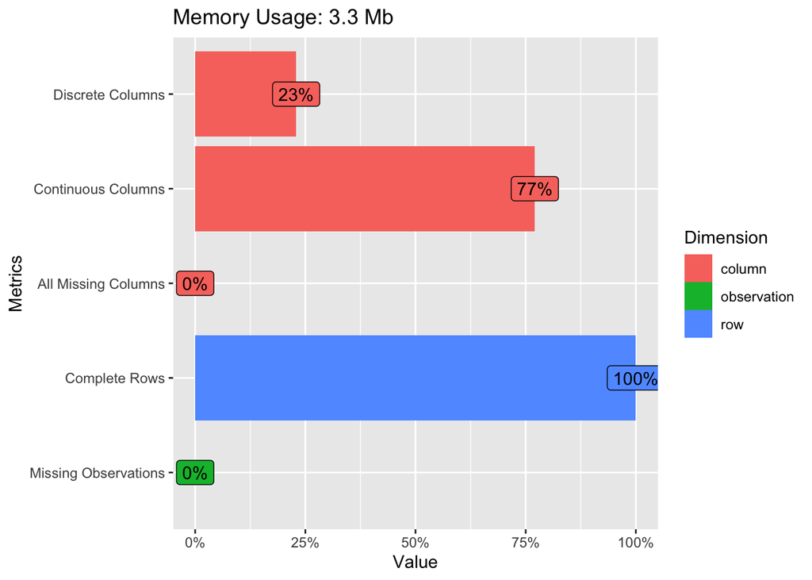

```r
plot_intro(loansNONAs)
```

### Plot 2

The bar plot shows the categorical variables in the data. According to the bar plot below, we can see some levels seem to have low frequencies, such as `joint` in the `application_type` and `Charged Off` in the `loan_status`.

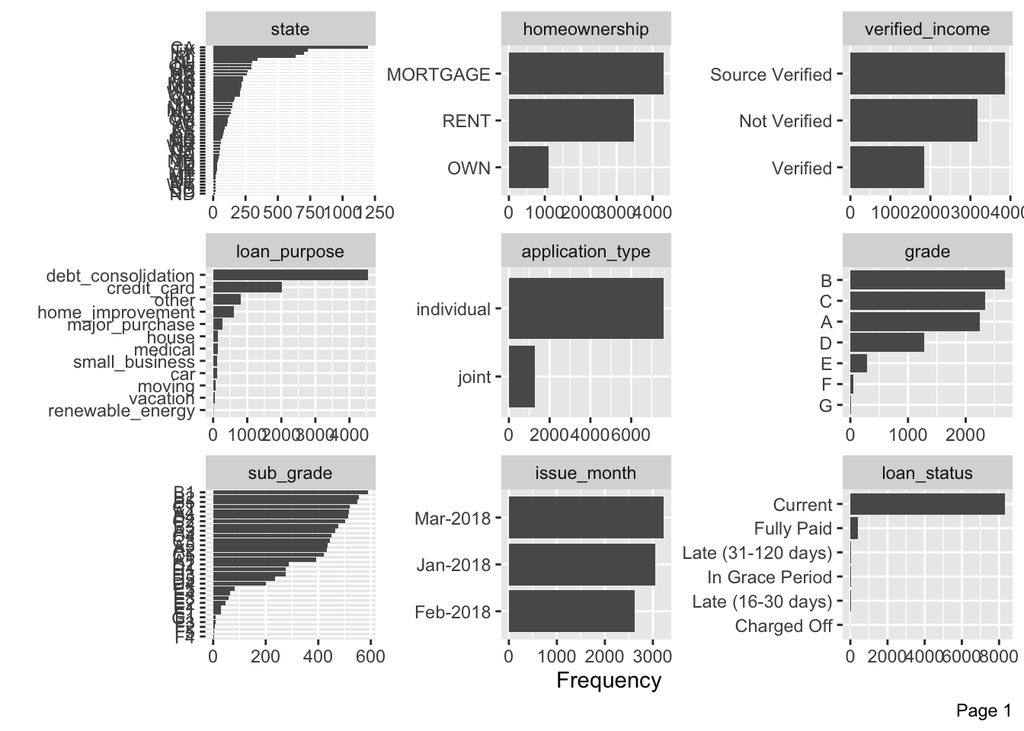

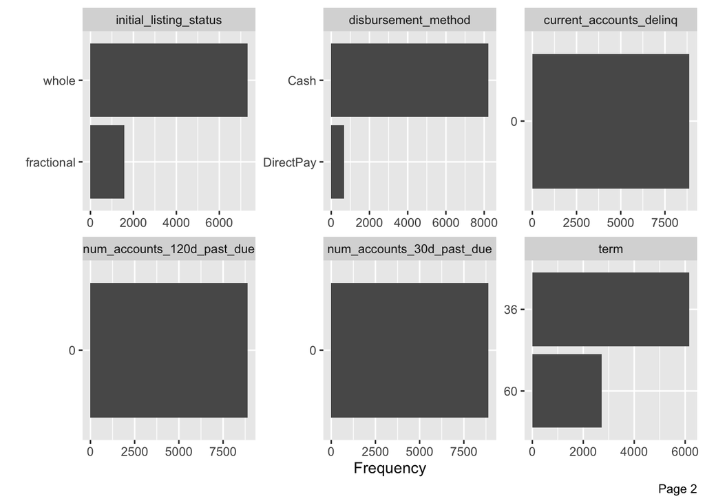

```r
plot_bar(loansNONAs)
```

### Plot 3

```r
loansNONAs %>%
  select_if(is.numeric) -> num_loans
correlation <- cor(num_loans)
```

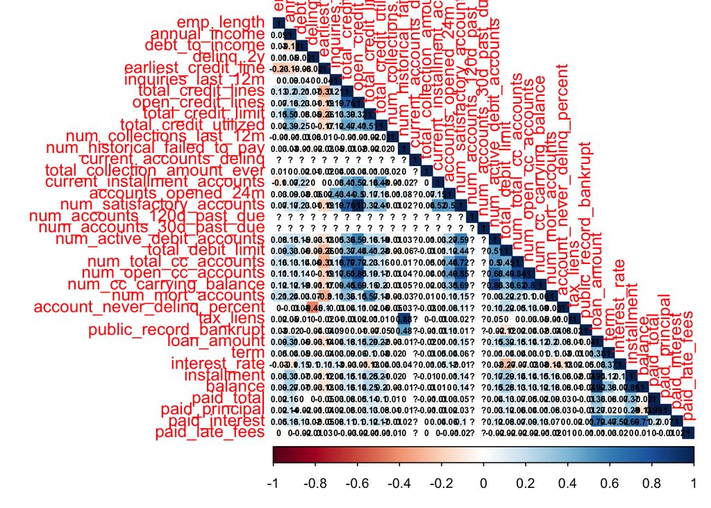

```r
corrplot(correlation, method="color", addCoef.col = "black", number.cex = 0.5, type = "lower")
```

### Plot 4

We can see the ownership status of the applicant’s residence is not the main factor to affect the Interest rate of the loan the applicant received. The median interest rates of these three are nearly identical.

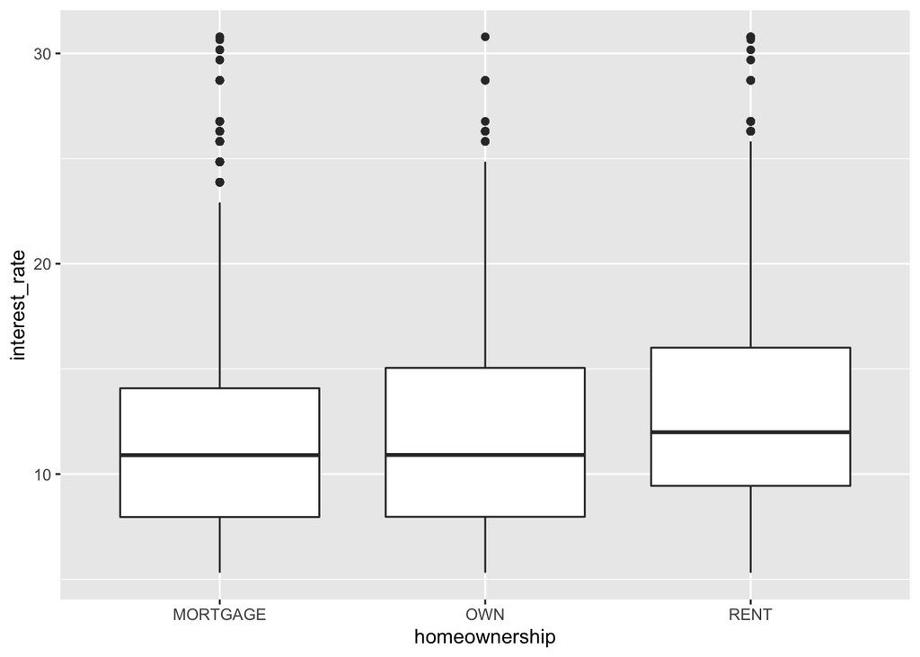

```r
loansNONAs %>%
  ggplot(aes(x = homeownership, y = interest_rate)) +
  geom_boxplot()
```

### Plot 5

According to the results, compared to other states, DC and NC have the higher verified average income, meaning that despite having higher incomes, these area’s people still want to apply for loans.

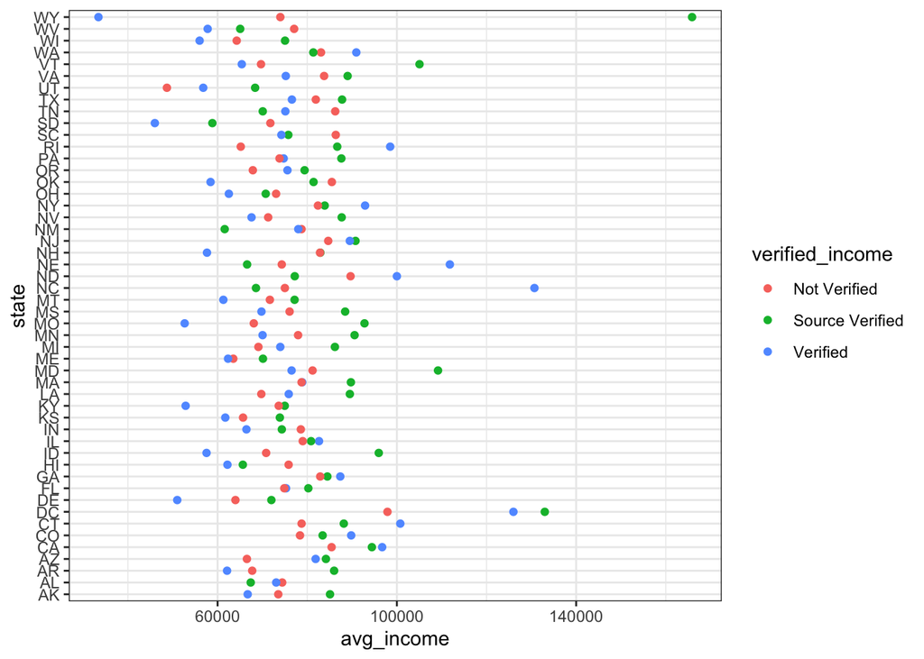

```r
loansNONAs %>%
  #filter(verified_income == "Verified") %>%
  group_by(state, verified_income) %>%
  summarise(avg_income = mean(annual_income)) %>%
  arrange(desc(avg_income)) %>%
  ggplot(aes(x = state, y = avg_income, color = verified_income)) +
  geom_point() +
  coord_flip() +
  theme_bw()
```

## Feature Selection

```r
loans_train_split <- initial_split(num_loans, prop = 0.8)
set.seed(1234)
loans_train <- training(loans_train_split)
loans_test <- testing(loans_train_split)

rand_forest_ranger_spec <-
  rand_forest() %>%
  set_engine('ranger', importance = "impurity") %>%
  set_mode('regression')
rand_forest_ranger_spec
```

```
## Random Forest Model Specification (regression)
##
## Engine-Specific Arguments:
##   importance = impurity
##
## Computational engine: ranger
```

```r
rf_fit <- fit(rand_forest_ranger_spec, interest_rate ~., data = loans_train)
rf_fit
```

```
## parsnip model object
##
## Fit time:  9.6s
## Ranger result
##
## Call:
##  ranger::ranger(x = maybe_data_frame(x), y = y, importance = ~"impurity",      num.threads = 1, verbose = FALSE, seed = sample.int(10^5,          1))
##
## Type:                             Regression
## Number of trees:                  500
## Sample size:                      7109
## Number of independent variables:  36
## Mtry:                             6
## Target node size:                 5
## Variable importance mode:         impurity
## Splitrule:                        variance
## OOB prediction error (MSE):       5.054262
## R squared (OOB):                  0.7990257
```

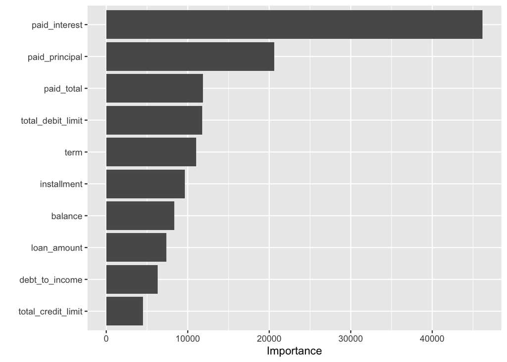

```r
vip(rf_fit$fit)
```

## Data Modeling

- Create a feature set and create a model which predicts interest rate using at least 2 algorithms. Describe any data cleansing that must be performed and analysis when examining the data.
- Visualize the test results and propose enhancements to the model, what would you do if you had more time. Also describe assumptions you made and your approach.

```r
# Bad result from the linear model
reg <- lm(interest_rate~ paid_interest+paid_principal+ paid_total+total_debit_limit+term,
          data = num_loans)
summary(reg)
```

```
##
## Call:
## lm(formula = interest_rate ~ paid_interest + paid_principal +
##     paid_total + total_debit_limit + term, data = num_loans)
##
## Residuals:
##      Min       1Q   Median       3Q      Max
## -10.3970  -2.8698  -0.6614   2.1786  19.2830
##
## Coefficients:
##                     Estimate Std. Error t value Pr(>|t|)
## (Intercept)        8.151e+00  1.759e-01  46.336   <2e-16 ***
## paid_interest     -4.051e-03  2.348e-02  -0.173    0.863
## paid_principal    -8.596e-03  2.348e-02  -0.366    0.714
## paid_total         8.594e-03  2.348e-02   0.366    0.714
## total_debit_limit -5.897e-05  1.593e-06 -37.014   <2e-16 ***
## term               7.114e-02  4.264e-03  16.685   <2e-16 ***
## ---
## Signif. codes:  0 '***' 0.001 '**' 0.01 '*' 0.05 '.' 0.1 ' ' 1
##
## Residual standard error: 3.91 on 8880 degrees of freedom
## Multiple R-squared:  0.3883, Adjusted R-squared:  0.3879
## F-statistic:  1127 on 5 and 8880 DF,  p-value: < 2.2e-16
```

We know that the variables `paid_interest` and `paid_principal` have a high correlations with the response variable. But if we add a regularizer, maybe we can improve the linear model. We will start to select the first five important variables above to the L1 model. That is, we will begin by attempting to use lasso regression model.

### Model 1: Lasso Regression with the optimal regularization

```r
num_loans %>%
  select(interest_rate, paid_interest, paid_principal, paid_total, total_debit_limit, term) -> loans_model_df

set.seed(1234)
loans_split <- initial_split(loans_model_df, prop = 0.8)
loans_train <- training(loans_split)
loans_test  <- testing(loans_split)
```

```r
lasso_spec <- linear_reg(mixture = 1, penalty = tune()) %>%
  set_mode("regression") %>%
  set_engine("glmnet")

lasso_rec <- recipe(interest_rate ~., data = loans_train) %>%
  step_normalize(all_predictors()) %>%
  step_zv(all_predictors())
```

create a workflow

```r
lasso_wf <- workflow() %>%
  add_model(lasso_spec) %>%
  add_recipe(lasso_rec)
```

#### Cross-Validation

create 10-Fold Cross-Validation in the training data set.

```r
set.seed(1234)
loans_folds <- vfold_cv(loans_train, strata = interest_rate, v = 10)
loans_folds$splits
```

```
## [[1]]
## <Analysis/Assess/Total>
## <6396/713/7109>
##
## [[2]]
## <Analysis/Assess/Total>
## <6397/712/7109>
##
## [[3]]
## <Analysis/Assess/Total>
## <6397/712/7109>
##
## [[4]]
## <Analysis/Assess/Total>
## <6398/711/7109>
##
## [[5]]
## <Analysis/Assess/Total>
## <6398/711/7109>
##
## [[6]]
## <Analysis/Assess/Total>
## <6399/710/7109>
##
## [[7]]
## <Analysis/Assess/Total>
## <6399/710/7109>
##
## [[8]]
## <Analysis/Assess/Total>
## <6399/710/7109>
##
## [[9]]
## <Analysis/Assess/Total>
## <6399/710/7109>
##
## [[10]]
## <Analysis/Assess/Total>
## <6399/710/7109>
```

#### Grid Search

Regularly predict the penalty 100 times using regular grids, with the penalty range limited to 0.00001 to 1.

```r
penalty_grid <- grid_regular(penalty(range = c(-5, 0)), levels = 100)
penalty_grid
```

```
## # A tibble: 100 x 1
##      penalty
##        <dbl>
##  1 0.00001
##  2 0.0000112
##  3 0.0000126
##  4 0.0000142
##  5 0.0000159
##  6 0.0000179
##  7 0.0000201
##  8 0.0000226
##  9 0.0000254
## 10 0.0000285
## # … with 90 more rows
```

### Tune

```r
tune_res <- tune_grid(
  lasso_wf,
  resamples = loans_folds,
  grid = penalty_grid
)
```

Display the each penalty on rmse and rsq, respectively.

```r
set.seed(1234)
tune_res %>%
  collect_metrics() %>%
  head()
```

```
## # A tibble: 6 x 7
##     penalty .metric .estimator  mean     n std_err .config
##       <dbl> <chr>   <chr>      <dbl> <int>   <dbl> <chr>
## 1 0.00001   rmse    standard   3.90     10 0.0284  Preprocessor1_Model001
## 2 0.00001   rsq     standard   0.389    10 0.00634 Preprocessor1_Model001
## 3 0.0000112 rmse    standard   3.90     10 0.0284  Preprocessor1_Model002
## 4 0.0000112 rsq     standard   0.389    10 0.00634 Preprocessor1_Model002
## 5 0.0000126 rmse    standard   3.90     10 0.0284  Preprocessor1_Model003
## 6 0.0000126 rsq     standard   0.389    10 0.00634 Preprocessor1_Model003
```

Display the best rmse and rsq values of penalty

```r
tune_res %>%
  show_best(metric = "rsq") %>%
  head(1)
```

```
## # A tibble: 1 x 7
##   penalty .metric .estimator  mean     n std_err .config
##     <dbl> <chr>   <chr>      <dbl> <int>   <dbl> <chr>
## 1  0.0433 rsq     standard   0.389    10 0.00634 Preprocessor1_Model073
```

```r
tune_res %>%
  show_best(metric = "rmse") %>%
  head(1)
```

```
## # A tibble: 1 x 7
##   penalty .metric .estimator  mean     n std_err .config
##     <dbl> <chr>   <chr>      <dbl> <int>   <dbl> <chr>
## 1  0.0305 rmse    standard    3.90    10  0.0286 Preprocessor1_Model070
```

We can see the best regularization value is 0.043 based on rsq, the the best regularization value is 0.030 based on rmse. We will use the smallest rmse to fit the model.

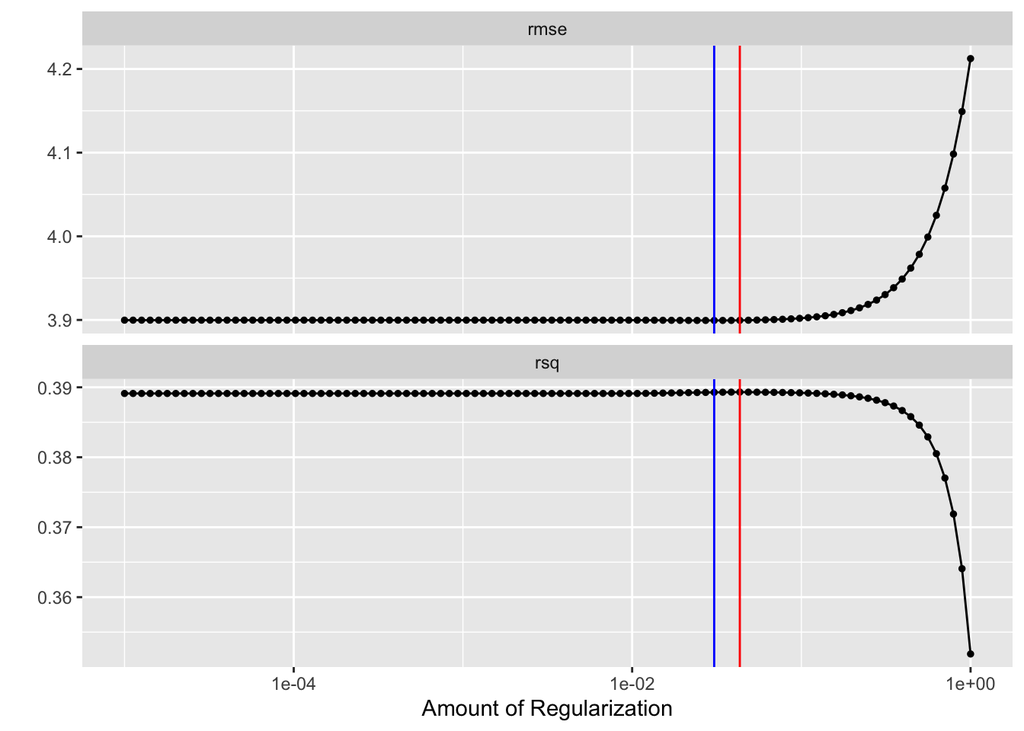

```r
tune_res %>%
  autoplot() +
  geom_vline(xintercept = 0.04328761, color = "red") +
  geom_vline(xintercept = 0.03053856, color = "blue")
```

#### The Best lambda

```r
best_rmse <- select_best(tune_res, metric = "rmse")
best_rmse
```

```
## # A tibble: 1 x 2
##   penalty .config
##     <dbl> <chr>
## 1  0.0305 Preprocessor1_Model070
```

```r
lasso_final <- finalize_workflow(lasso_wf, best_rmse)

lasso_final_fit <- fit(lasso_final, data = loans_train)
```

### Lasso Performance

```r
augment(lasso_final_fit, new_data = loans_test) %>%
  yardstick::rmse(truth = interest_rate, estimate = .pred)
```

```
## # A tibble: 1 x 3
##   .metric .estimator .estimate
##   <chr>   <chr>          <dbl>
## 1 rmse    standard        3.96
```

### Visualization

The range of `interest_rate` is from 5.31 to 30.94 from the original data set. Based on the plot below, we can conclude that the model does not work well, tuning $\lambda$ appears to have no obvious benefit in the model. We should try to reduce the $RMSE$.

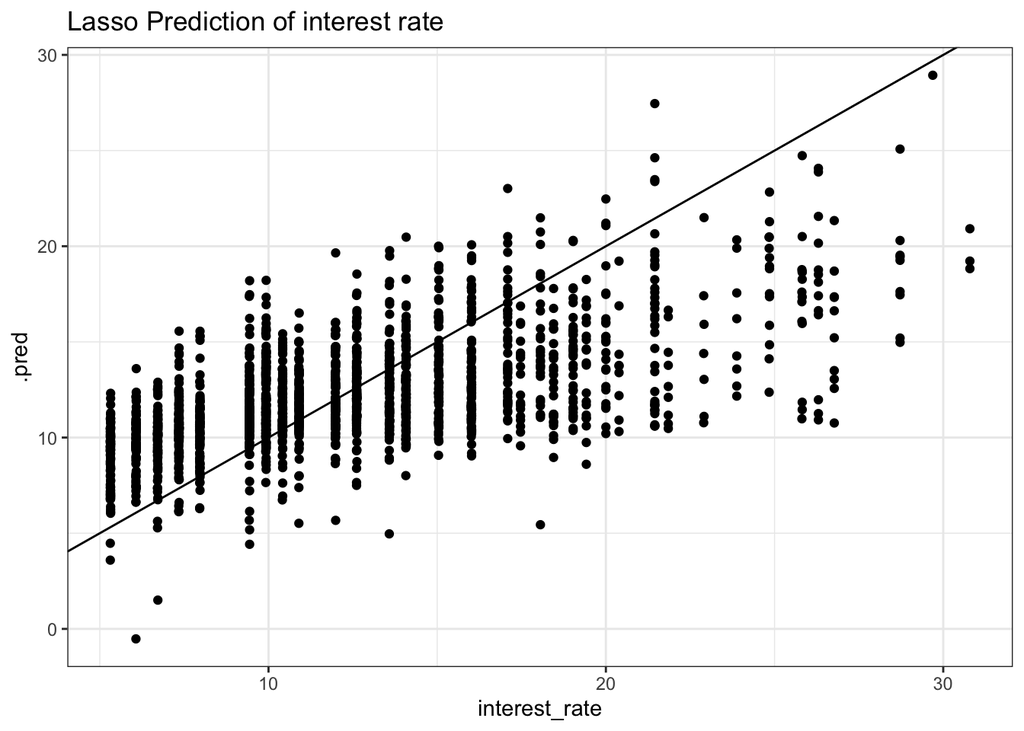

```r
augment(lasso_final_fit, new_data = loans_test) %>%
  ggplot(aes(interest_rate, .pred)) +
  geom_abline(slope = 1, intercept = 0) +
  geom_point() +
  theme_bw() +
  ggtitle("Lasso Prediction of interest rate")
```

The number of observations is greater then the number of features, so that the L1 and L2 regularization methods are not the wise choices.

### Model 2: Random Forest with all numerical predictors

Next, we try to add all numerical variables as predictors. That is, 36 variables as X and 1 target variable as y. This time we will use random forest algorithm.

```r
num_loans %>%
  #this is our target variable
  select(-interest_rate) %>%
  length()
```

```
## [1] 36
```

Taking 80 % observations as a training set and taking 20 % observations as a testing set.

```r
loans_split2 <- initial_split(num_loans, prop = 0.8)
set.seed(1234)
loans_train2 <- training(loans_split2)
loans_test2 <- testing(loans_split2)
```

As usual, we fit the model. In comparison to the lasso regression, we discovered that the rmse of random forest is dramatically reduced from 3.96 to 1.28.

#### Random Forest Performance

```r
set.seed(1234)
# mtry = .cols(): the number of columns in the predictor matrix is used
rd_spec <- rand_forest(mtry = .cols()) %>%
  set_engine("randomForest", importance = TRUE) %>%
  set_mode("regression")

rd_fit <- fit(rd_spec, interest_rate ~ ., data = loans_train2)
augment(rd_fit, new_data = loans_test2) %>%
  yardstick::rmse(truth = interest_rate, estimate = .pred)
```

```
## # A tibble: 1 x 3
##   .metric .estimator .estimate
##   <chr>   <chr>          <dbl>
## 1 rmse    standard        1.28
```

#### Visualization

We can also create a quick scatter plot between the true and predicted value to see if we can make any diagnostics. The predicted values are almost closer to the ground truths.

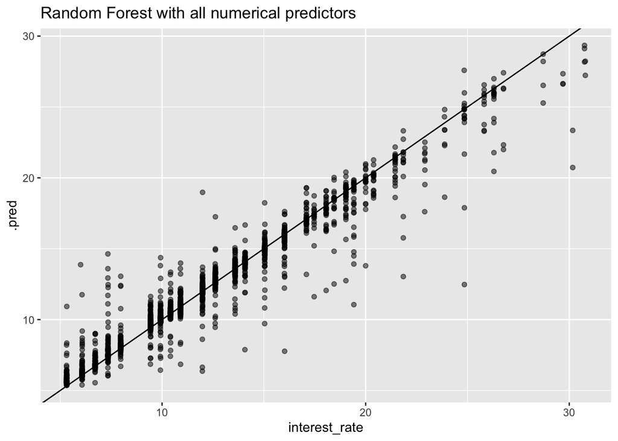

```r
augment(rd_fit, new_data = loans_test2) %>%
  ggplot(aes(interest_rate, .pred)) +
  geom_abline() +
  geom_point(alpha = 0.5) +
  ggtitle("Random Forest with all numerical predictors")
```

Next, let’s take a look at the variable importance

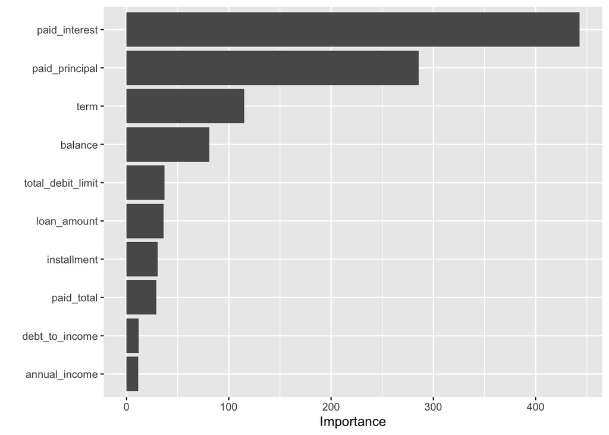

```r
vip(rd_fit)
```

### Model 3: Random Forest with only 3 predictors

Now we only add top three importance variables in the random forest model. In reality, a smaller predictor in ML models can save time for data collection. And we can rapidly run the model and make marketing strategies more easily.

```r
num_loans %>%
  select(interest_rate, paid_interest, paid_principal, term) -> loans_threeFeatures

loans_split3 <- initial_split(loans_threeFeatures, prop = 0.8)
set.seed(1234)
loans_train3 <- training(loans_split3)
loans_test3 <- testing(loans_split3)
```

The $RMSE$ is still less than 2, indicating that the model is still performing well. The advantage is that even though we only have three predictors, we can still keep the model performing well.

#### Random Forest Performance

```r
set.seed(1234)
# mtry = .cols(): the number of columns in the predictor matrix is used
rd_spec2 <- rand_forest(mtry = .cols()) %>%
  set_engine("randomForest", importance = TRUE) %>%
  set_mode("regression")

rd_fit2 <- fit(rd_spec2, interest_rate ~ ., data = loans_train3)
augment(rd_fit2, new_data = loans_test3) %>%
  yardstick::rmse(truth = interest_rate, estimate = .pred)
```

```
## # A tibble: 1 x 3
##   .metric .estimator .estimate
##   <chr>   <chr>          <dbl>
## 1 rmse    standard        1.41
```

#### Visualization

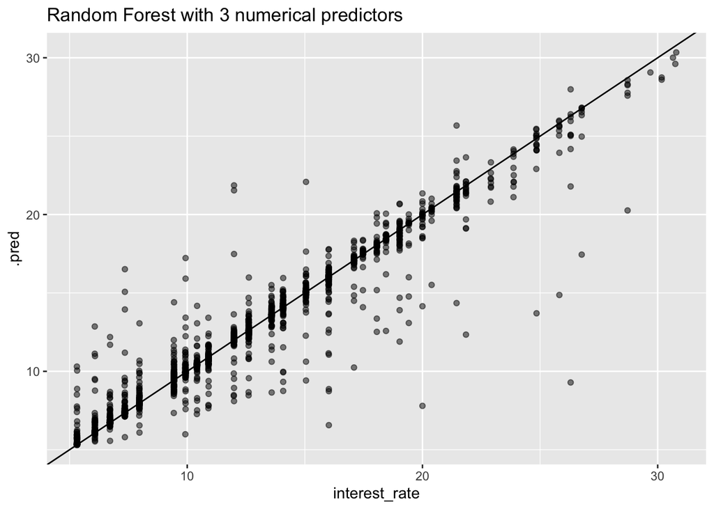

```r
augment(rd_fit2, new_data = loans_test3) %>%
  ggplot(aes(interest_rate, .pred)) +
  geom_abline() +
  geom_point(alpha = 0.5) +
  ggtitle("Random Forest with 3 numerical predictors")
```

## Conclusion

Finally, if we need to predict the `interest_rate` based on given data, I recommend using `paid interest`, `paid principal`, and `term` by running the random forest algorithm to quickly provide business insights with limited time.

If I have more time, I’ll use a recursive feature elimination algorithm and combine all numerical and categorical variables to perform feature selection. `library(caret)` is a good R package to do a feature selection. Secondly, we removed some observations due to the large number of NAs. There are some approaches that can be taken in this situation. For example, predicting missing values or replacing NAs with mean/medians mode. Finally, I believe we should try to reduce the features to make it more efficient, so if I have time, I will try to run more 3-5 feature combinations in different regression models.